# matplotlib.pyplot.tight_layout

**matplotlib.pyplot.tight_layout(*, *pad=1.08*, *h_pad=None*, *w_pad=None*, *rect=None*)[[source]](https://github.com/matplotlib/matplotlib/blob/v3.7.1/lib/matplotlib/pyplot.py#L2347-L2349)**

Adjust the padding between and around subplots.

To exclude an artist on the Axes from the bounding box calculation that determines the subplot parameters (i.e. legend, or annotation), set `a.set_in_layout(False)` for that artist.

**Parameters:**

**pad**float, default: 1.08**

Padding between the figure edge and the edges of subplots, as a fraction of the font size.

**h_pad, w_pad**float, default: *pad**

Padding (height/width) between edges of adjacent subplots, as a fraction of the font size.

**rect**tuple (left, bottom, right, top), default: (0, 0, 1, 1)**

A rectangle in normalized figure coordinates into which the whole subplots area (including labels) will fit.

See also

**`Figure.set_layout_engine`**

**`pyplot.tight_layout`**

## Examples using `matplotlib.pyplot.tight_layout`

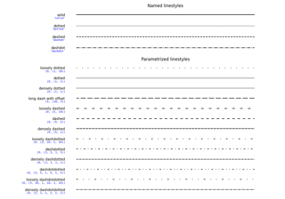

[Linestyles](https://matplotlib.org/stable/gallery/lines_bars_and_markers/linestyles.html#sphx-glr-gallery-lines-bars-and-markers-linestyles-py)

Linestyles

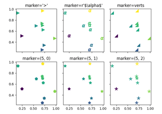

[Marker examples](https://matplotlib.org/stable/gallery/lines_bars_and_markers/scatter_star_poly.html#sphx-glr-gallery-lines-bars-and-markers-scatter-star-poly-py)

Marker examples

[Creating annotated heatmaps](https://matplotlib.org/stable/gallery/images_contours_and_fields/image_annotated_heatmap.html#sphx-glr-gallery-images-contours-and-fields-image-annotated-heatmap-py)

Creating annotated heatmaps

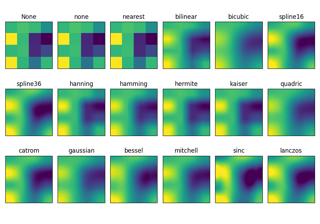

[Interpolations for imshow](https://matplotlib.org/stable/gallery/images_contours_and_fields/interpolation_methods.html#sphx-glr-gallery-images-contours-and-fields-interpolation-methods-py)

Interpolations for imshow

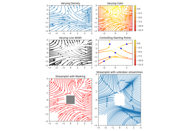

[Streamplot](https://matplotlib.org/stable/gallery/images_contours_and_fields/plot_streamplot.html#sphx-glr-gallery-images-contours-and-fields-plot-streamplot-py)

Streamplot

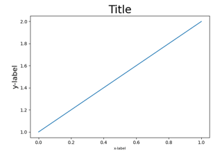

[Resizing axes with tight layout](https://matplotlib.org/stable/gallery/subplots_axes_and_figures/demo_tight_layout.html#sphx-glr-gallery-subplots-axes-and-figures-demo-tight-layout-py)

Resizing axes with tight layout

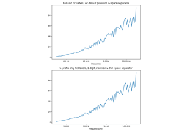

[Labeling ticks using engineering notation](https://matplotlib.org/stable/gallery/text_labels_and_annotations/engineering_formatter.html#sphx-glr-gallery-text-labels-and-annotations-engineering-formatter-py)

Labeling ticks using engineering notation

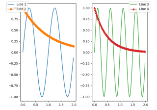

[Figure legend demo](https://matplotlib.org/stable/gallery/text_labels_and_annotations/figlegend_demo.html#sphx-glr-gallery-text-labels-and-annotations-figlegend-demo-py)

Figure legend demo

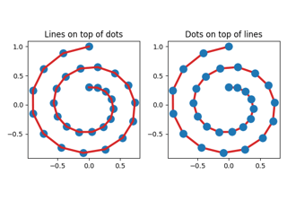

[Zorder Demo](https://matplotlib.org/stable/gallery/misc/zorder_demo.html#sphx-glr-gallery-misc-zorder-demo-py)

Zorder Demo

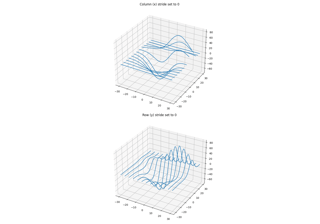

[3D wireframe plots in one direction](https://matplotlib.org/stable/gallery/mplot3d/wire3d_zero_stride.html#sphx-glr-gallery-mplot3d-wire3d-zero-stride-py)

3D wireframe plots in one direction

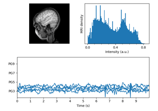

[MRI with EEG](https://matplotlib.org/stable/gallery/specialty_plots/mri_with_eeg.html#sphx-glr-gallery-specialty-plots-mri-with-eeg-py)

MRI with EEG

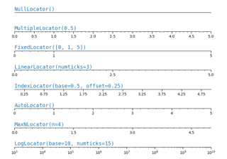

[Tick locators](https://matplotlib.org/stable/gallery/ticks/tick-locators.html#sphx-glr-gallery-ticks-tick-locators-py)

Tick locators

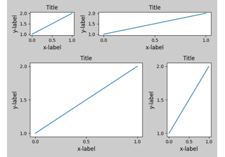

[Tight Layout guide](https://matplotlib.org/stable/tutorials/intermediate/tight_layout_guide.html#sphx-glr-tutorials-intermediate-tight-layout-guide-py)

Tight Layout guide

© 2012–2023 Matplotlib Development Team. All rights reserved.  
Licensed under the Matplotlib License Agreement.  
https://matplotlib.org/stable/api/_as_gen/matplotlib.pyplot.tight_layout.html